# Estudios de Informática, Multimedia y Telecomunicaciones

# Práctica 2: ¿Cómo realizar la limpieza y análisis de datos?

Tipología y ciclo de vida de los datos

Autores: Ouassim Aouattah Akandouch, Juan Andrés Dávila

Enero 2023

# 1 Descripción del dataset ¿Por qué es importante y qué pregunta/problema pretende responder?

Este dataset, llamado *Heart Attack Analysis & Prediction Dataset*, contiene información sobre pacientes que han sufrido o podrían sufrir un ataque al corazón. Incluye atributos como la edad y el sexo del paciente, si ha experimentado angina inducida por ejercicio, el número de vasos principales, el tipo de dolor en el pecho, la presión arterial en reposo, el colesterol, los resultados electrocardiográficos en reposo, la frecuencia cardíaca máxima lograda, y finalmente si tiene más o menos probabilidades de sufrir un ataque al corazón.

Este dataset es importante ya que el ataque al corazón es una de las principales causas de mortalidad a nivel mundial. El análisis de estos datos puede ayudar a identificar patrones y factores de riesgo relacionados con los ataques cardíacos, lo que permitiría a los médicos y científicos de la salud tomar medidas preventivas y mejorar los tratamientos.Se puede responder preguntas como ¿Qué factor o variables son los de mayor incidencia cuando una persona sufre de un ataque al corazón?o ¿Las mujeres son mas propensas a tener este tipo de enfermedades? ¿es el colesterol un factor más determinante para un ataque cardiaco que la edad de la persona?

Revisamos la descripción de las variables contenidas en el fichero y los tipos de cada una y a continuación Construimos un pequeño diccionario de datos utilizando la documentación auxiliar.

## 1.1 Objetivos

Al analizar el dataset “Heart Attack Analysis & Prediction Dataset”, se pueden establecer varios objetivos metodológicos:

1. Análisis exploratorio de los datos: estudiar las variables y los patrones de los datos para obtener una comprensión general de los datos y detectar posibles problemas o outliers.
2. Identificar factores de riesgo: utilizar técnicas estadísticas para identificar variables que estén relacionadas con un mayor riesgo de sufrir un ataque al corazón.
3. Desarrollar modelos de predicción: utilizar algoritmos de aprendizaje automático para desarrollar modelos que puedan predecir el riesgo de sufrir un ataque al corazón en base a los datos de los pacientes.
4. Evaluar el rendimiento de los modelos: medir la precisión y el rendimiento de los modelos desarrollados para evaluar su capacidad para predecir el riesgo de sufrir un ataque al corazón.
5. Identificar las variables más importantes: Utilizar técnicas de selección de características para identificar las variables más importantes en la predicción de riesgo de un ataque cardíaco.
6. Utilizar el modelo para la toma de decisiones: Utilizar el modelo generado para la toma de decisiones clínicas y asesoramiento a pacientes.

# 2 Integración y selección

Como se indicó en el apartado anterior existen muchas variables con las cuales se pueden trabajar para poder realizar un análisis por lo que empezaremos cargando el fichero de datos.

```r
path = 'heart.csv'
df <- read.csv(path, row.names=NULL)
```

Verificamos la estructura del juego de datos principal. Mostramos el número de columnas que tenemos y ejemplos de los contenidos de las filas.

```r
structure = str(df)
```

```
## 'data.frame':    303 obs. of  14 variables:
##  $ age     : int  63 37 41 56 57 57 56 44 52 57 ...
##  $ sex     : int  1 1 0 1 0 1 0 1 1 1 ...
##  $ cp      : int  3 2 1 1 0 0 1 1 2 2 ...
##  $ trtbps  : int  145 130 130 120 120 140 140 120 172 150 ...
##  $ chol    : int  233 250 204 236 354 192 294 263 199 168 ...
##  $ fbs     : int  1 0 0 0 0 0 0 0 1 0 ...
##  $ restecg : int  0 1 0 1 1 1 0 1 1 1 ...
##  $ thalachh: int  150 187 172 178 163 148 153 173 162 174 ...
##  $ exng    : int  0 0 0 0 1 0 0 0 0 0 ...
##  $ oldpeak : num  2.3 3.5 1.4 0.8 0.6 0.4 1.3 0 0.5 1.6 ...
##  $ slp     : int  0 0 2 2 2 1 1 2 2 2 ...
##  $ caa     : int  0 0 0 0 0 0 0 0 0 0 ...
##  $ thall   : int  1 2 2 2 2 1 2 3 3 2 ...
##  $ output  : int  1 1 1 1 1 1 1 1 1 1 ...
```

```r
summary(df)
```

```
##       age             sex               cp            trtbps
##  Min.   :29.00   Min.   :0.0000   Min.   :0.000   Min.   : 94.0
##  1st Qu.:47.50   1st Qu.:0.0000   1st Qu.:0.000   1st Qu.:120.0
##  Median :55.00   Median :1.0000   Median :1.000   Median :130.0
##  Mean   :54.37   Mean   :0.6832   Mean   :0.967   Mean   :131.6
##  3rd Qu.:61.00   3rd Qu.:1.0000   3rd Qu.:2.000   3rd Qu.:140.0
##  Max.   :77.00   Max.   :1.0000   Max.   :3.000   Max.   :200.0
##       chol            fbs            restecg          thalachh
##  Min.   :126.0   Min.   :0.0000   Min.   :0.0000   Min.   : 71.0
##  1st Qu.:211.0   1st Qu.:0.0000   1st Qu.:0.0000   1st Qu.:133.5
##  Median :240.0   Median :0.0000   Median :1.0000   Median :153.0
##  Mean   :246.3   Mean   :0.1485   Mean   :0.5281   Mean   :149.6
##  3rd Qu.:274.5   3rd Qu.:0.0000   3rd Qu.:1.0000   3rd Qu.:166.0
##  Max.   :564.0   Max.   :1.0000   Max.   :2.0000   Max.   :202.0
##       exng           oldpeak          slp             caa
##  Min.   :0.0000   Min.   :0.00   Min.   :0.000   Min.   :0.0000
##  1st Qu.:0.0000   1st Qu.:0.00   1st Qu.:1.000   1st Qu.:0.0000
##  Median :0.0000   Median :0.80   Median :1.000   Median :0.0000
##  Mean   :0.3267   Mean   :1.04   Mean   :1.399   Mean   :0.7294
##  3rd Qu.:1.0000   3rd Qu.:1.60   3rd Qu.:2.000   3rd Qu.:1.0000
##  Max.   :1.0000   Max.   :6.20   Max.   :2.000   Max.   :4.0000
##      thall           output
##  Min.   :0.000   Min.   :0.0000
##  1st Qu.:2.000   1st Qu.:0.0000
##  Median :2.000   Median :1.0000
##  Mean   :2.314   Mean   :0.5446
##  3rd Qu.:3.000   3rd Qu.:1.0000
##  Max.   :3.000   Max.   :1.0000
```

Vemos que tenemos **14** variables y **303** registros.

# 3 Limpieza de los datos

## 3.1 Valores nulos o vacíos

Un paso esencial será la limpieza de datos, mirando si hay valores vacíos o nulos.

```r
colSums(is.na(df))
```

```
##      age      sex       cp   trtbps     chol      fbs  restecg thalachh
##        0        0        0        0        0        0        0        0
##     exng  oldpeak      slp      caa    thall   output
##        0        0        0        0        0        0
```

```r
colSums(df == "")
```

```
##      age      sex       cp   trtbps     chol      fbs  restecg thalachh
##        0        0        0        0        0        0        0        0
##     exng  oldpeak      slp      caa    thall   output
##        0        0        0        0        0        0
```

Vemos que no hay valores nulos en los datos ni existen campos llenos de espacios en blanco. Procedemos a convertir a factores las variables correspondientes a este tipo.

```r
df$sex <- factor(df$sex, levels = c(0, 1), labels = c("Female", "Male"))
df$exng <- factor(df$exng, levels = c(0, 1), labels = c("No", "Yes"))
df$cp <- factor(df$cp, levels = c(0, 1, 2, 3), labels = c("Typical Angina", "Atypical Angina", "Non-anginal pain", "Asymptomatic"))
df$fbs <- factor(df$fbs, levels = c(0, 1), labels = c("False", "True"))
df$restecg <- factor(df$restecg, levels = c(0, 1, 2), labels = c("Normal", "ST-T wave abnormality", "Left ventricular hypertrophy"))
df$thall <- factor(df$thall)
```

## 3.2 Valores extremos

A continuación, analizaremos los posibles valores extremos de nuestro juego de datos.

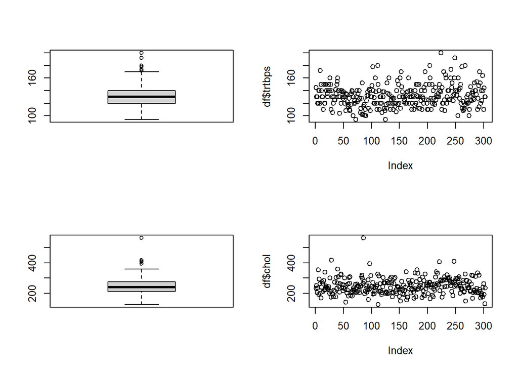

```r
par(mfrow = c(2,2))

boxplot(df$trtbps)
plot(df$trtbps, )

boxplot(df$chol)
plot(df$chol, )
```

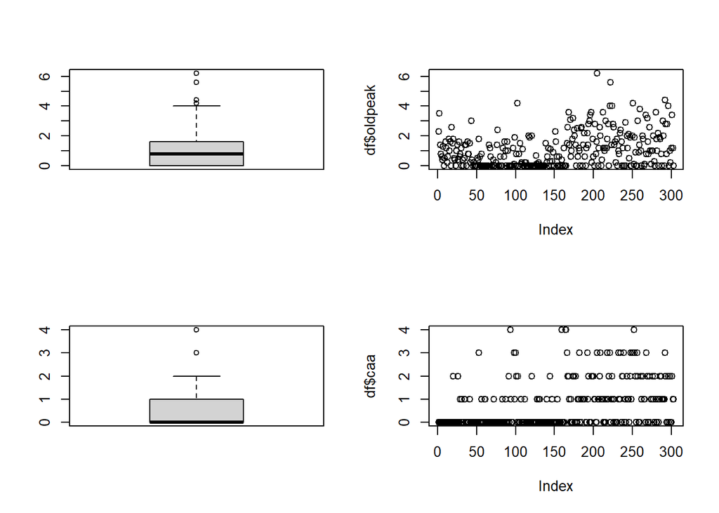

```r
boxplot(df$oldpeak)
plot(df$oldpeak, )

boxplot(df$caa)
plot(df$caa, )
```

```r
# Cálculo del rango intercuartil (iqr) para cada variable
iqr_trtbps <- quantile(df$trtbps, 0.75) - quantile(df$trtbps, 0.25)
iqr_chol <- quantile(df$chol, 0.75) - quantile(df$chol, 0.25)
iqr_oldpeak <- quantile(df$oldpeak, 0.75) - quantile(df$oldpeak, 0.25)
iqr_caa <- quantile(df$caa, 0.75) - quantile(df$caa, 0.25)

# Cálculo de los límites superior e inferior para cada variable
upper_trtbps <- quantile(df$trtbps, 0.75) + 1.5*iqr_trtbps
lower_trtbps <- quantile(df$trtbps, 0.25) - 1.5*iqr_trtbps
upper_chol <- quantile(df$chol, 0.75) + 1.5*iqr_chol
lower_chol <- quantile(df$chol, 0.25) - 1.5*iqr_chol
upper_oldpeak <- quantile(df$oldpeak, 0.75) + 1.5*iqr_oldpeak
lower_oldpeak <- quantile(df$oldpeak, 0.25) - 1.5*iqr_oldpeak
upper_caa <- quantile(df$caa, 0.75) + 1.5*iqr_caa
lower_caa <- quantile(df$caa, 0.25) - 1.5*iqr_caa

# Eliminar los valores atípicos
df <- df[df$trtbps <= upper_trtbps & df$trtbps >= lower_trtbps,]
df <- df[df$chol <= upper_chol & df$chol >= lower_chol,]
df <- df[df$oldpeak <= upper_oldpeak & df$oldpeak >= lower_oldpeak,]
df <- df[df$caa <= upper_caa & df$caa >= lower_caa,]
```

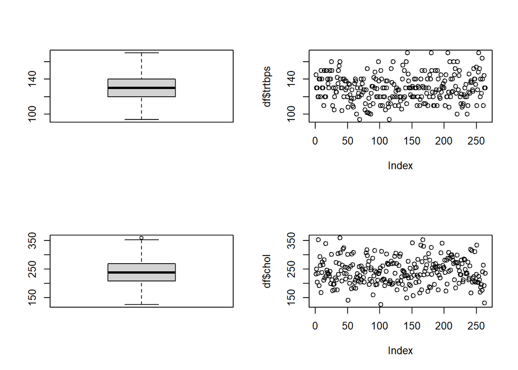

```r
par(mfrow = c(2,2))

boxplot(df$trtbps)
plot(df$trtbps, )

boxplot(df$chol)
plot(df$chol, )
```

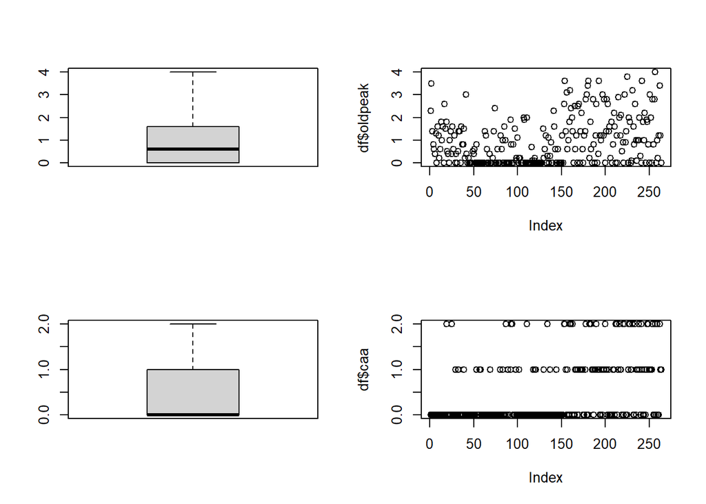

```r
boxplot(df$oldpeak)
plot(df$oldpeak, )

boxplot(df$caa)
plot(df$caa, )
```

# 4 Análisis de los datos

## 4.1 Selección de los grupos de datos que se quieren analizar/comparar

En nuestro análisis compararemos los pacientes que sufrieron un ataque cardíaco con los que no. Lo haremos mediante la selección de dos grupos de datos basados en el valor de la variable `output`: pacientes con valor de `output` igual a 1 (pacientes que sufrieron un ataque cardíaco) y pacientes con valor de `output` igual a 0 (pacientes que no sufrieron un ataque cardíaco). Con estos dos grupos seleccionados, podremos aplicar diferentes métodos de análisis estadístico para comparar las diferencias entre los grupos en las diferentes variables del dataset.

```r
test <- df[,names(df) %in% c("chol", "output","age")]
structure= str(test)
```

```
## 'data.frame':    264 obs. of  3 variables:
##  $ age   : int  63 37 41 56 57 57 56 44 57 54 ...
##  $ chol  : int  233 250 204 236 354 192 294 263 168 239 ...
##  $ output: int  1 1 1 1 1 1 1 1 1 1 ...
```

## 4.2 Comprobación de la normalidad y homogeneidad de la varianza

En cuanto al primer dataset creado vamos a comprobar la normalidad la variable col

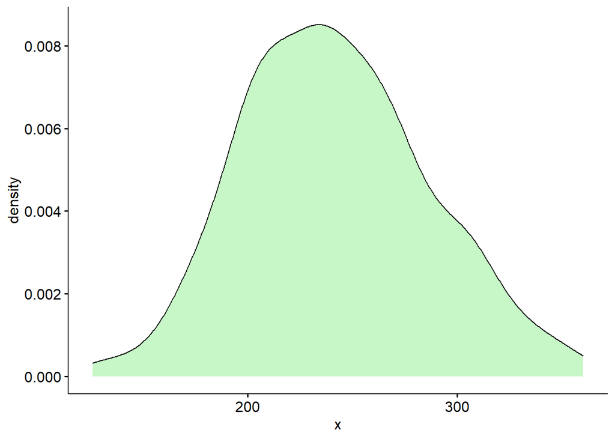

```r
grid.arrange((ggdensity(test$chol, fill = "lightgreen")),ncol=1)
```

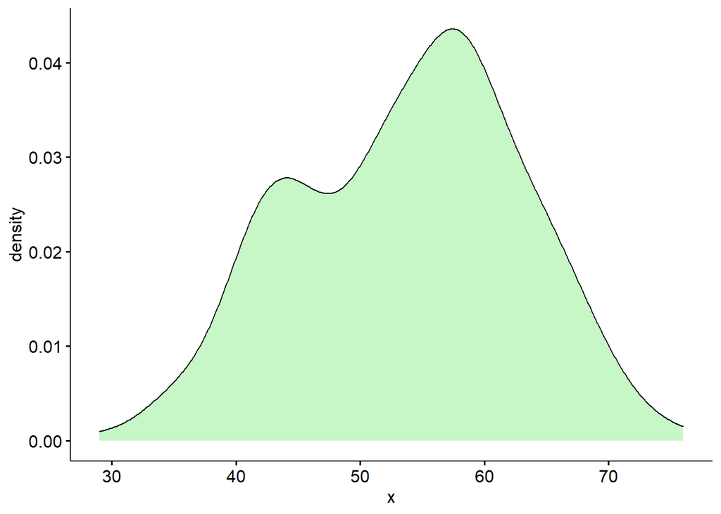

```r
grid.arrange((ggdensity(test$age, fill = "lightgreen")),ncol=1)
```

## 4.3 Aplicación de pruebas estadísticas para comparar los grupos de datos.

### 4.3.1 Correlaciones

La librería PerformanceAnalytics en R incluye una función llamada chart.Correlation, la cual permite generar un gráfico de relación entre variables con elementos como histogramas, funciones de densidad, líneas de regresión suavizadas y coeficientes de correlación con indicadores de significancia estadística (representado por estrellas, donde ausencia de estrellas indica que la variable no es estadísticamente significativa, mientras que una, dos y tres estrellas indican significancia estadística al nivel del 10%, 5% y 1%, respectivamente).

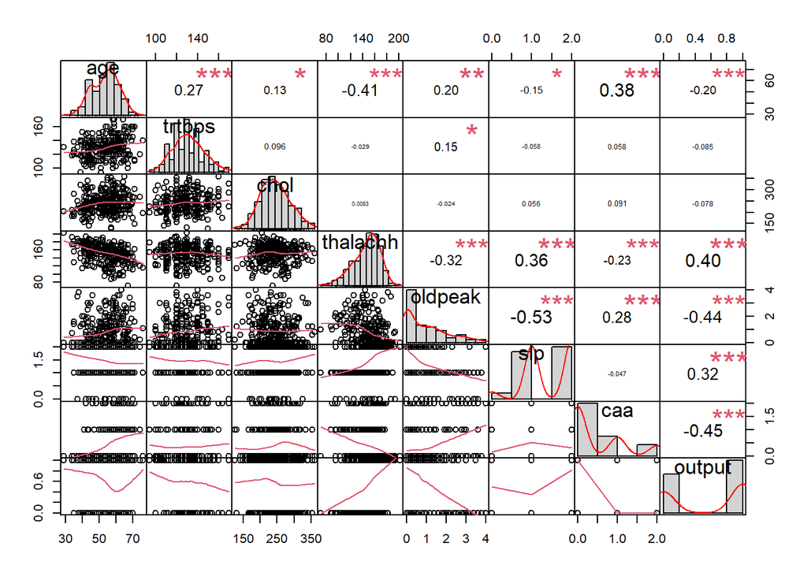

```r
if(!require("PerformanceAnalytics")) install.packages("PerformanceAnalytics"); library(PerformanceAnalytics)

df_num <- df[,sapply(df,is.numeric)]
df_num <- df_num[complete.cases(df_num),]
chart.Correlation(df_num, histogram = TRUE, method = "pearson")
```

### 4.3.3 Regresión logística

Queremos analizar la relación entre las variables y el riesgo de sufrir un ataque cardíaco. Para ello utilizaremos una regresión logística, tomando como variable dependiente `output` i un conjunto de variables explicativas de la base de datos, que iremos eliminando o añadiendo según creamos conveniente. Para poder estimar de forma más objetiva la precisión del modelo, separaremos el conjunto de datos en dos partes: el conjunto de entrenamiento (training) y el conjunto de prueba (testing). Ajustaremos el modelo de regresión logística con el conjunto de entrenamiento, y evaluaremos la precisión con el conjunto de prueba.

#### 4.3.3.1 Generación de los conjuntos de entrenamiento y de test

Generaremos los conjuntos de datos para entrenar el modelo (training) y para testarlo (testing). En este caso, fijaremos el tamaño de la muestra de entrenamiento a un 80% del original.

```r
if(!require("caret")) install.packages("caret"); library(caret)

set.seed(888)

# Crear partición de los datos
partition <- createDataPartition(df$output, p = 0.8, list = FALSE)

# Generar conjunto de entrenamiento
training_data <- df[sample(partition), ]

# Generar conjunto de prueba
testing_data <- df[-sample(partition), ]
```

#### 4.3.3.2 Estimación del modelo con el conjunto de entrenamiento e interpretación

Procedemos a seleccionar las variables explicativas y a entrenar el modelo de regresión. Empezamos seleccionando todos los atributos del conjunto de datos.

```r
# Seleccionar variables explicativas
explanatory_vars <- names(training_data)[!names(training_data) %in% c("")]

# Estimar modelo de regresión logística
log_model <- glm(output ~ ., data = training_data[, explanatory_vars], family = binomial)

summary(log_model)
```

```
##
## Call:
## glm(formula = output ~ ., family = binomial, data = training_data[,
##     explanatory_vars])
##
## Deviance Residuals:
##     Min       1Q   Median       3Q      Max
## -2.8812  -0.1901   0.1482   0.5308   2.8725
##
## Coefficients:
##                                       Estimate Std. Error z value Pr(>|z|)
## (Intercept)                         -2.526e+00  4.112e+00  -0.614 0.539018
## age                                  2.848e-02  3.068e-02   0.928 0.353262
## sexMale                             -2.089e+00  6.774e-01  -3.084 0.002044 **
## cpAtypical Angina                    9.735e-01  6.473e-01   1.504 0.132605
## cpNon-anginal pain                   2.289e+00  6.712e-01   3.409 0.000651 ***
## cpAsymptomatic                       2.448e+00  8.239e-01   2.971 0.002968 **
## trtbps                              -2.095e-02  1.574e-02  -1.331 0.183184
## chol                                -4.605e-03  6.301e-03  -0.731 0.464889
## fbsTrue                              4.511e-01  8.227e-01   0.548 0.583465
## restecgST-T wave abnormality         6.658e-01  4.683e-01   1.422 0.155117
## restecgLeft ventricular hypertrophy  1.205e+01  1.455e+03   0.008 0.993394
## thalachh                             2.614e-02  1.526e-02   1.713 0.086719 .
## exngYes                             -5.089e-01  5.815e-01  -0.875 0.381491
## oldpeak                             -6.838e-01  3.066e-01  -2.231 0.025714 *
## slp                                  7.165e-01  4.384e-01   1.634 0.102202
## caa                                 -1.740e+00  4.128e-01  -4.216 2.48e-05 ***
## thall1                               4.066e+00  2.530e+00   1.607 0.108023
## thall2                               2.432e+00  2.320e+00   1.048 0.294704
## thall3                               8.337e-01  2.324e+00   0.359 0.719756
## ---
## Signif. codes:  0 '***' 0.001 '**' 0.01 '*' 0.05 '.' 0.1 ' ' 1
##
## (Dispersion parameter for binomial family taken to be 1)
##
##     Null deviance: 285.52  on 211  degrees of freedom
## Residual deviance: 130.80  on 193  degrees of freedom
## AIC: 168.8
##
## Number of Fisher Scoring iterations: 14
```

Los puntos clave de los resultados de una regresión logística son los coeficientes de regresión, los valores de p y las medidas de ajuste del modelo.

1. Los coeficientes de regresión: Estos indican la dirección y magnitud de la relación entre cada variable independiente y la variable dependiente. Un coeficiente positivo indica una relación positiva entre la variable independiente y la variable dependiente, mientras que un coeficiente negativo indica una relación negativa. En este caso, un ejemplo de esto es que `cpNon-anginal pain` tiene un coeficiente positivo de 2.289 y significativamente alto, esto indica que tiene una relación positiva con la probabilidad de sufrir un ataque cardíaco.
2. Los valores de p: Estos indican la probabilidad de que el coeficiente de regresión sea cero (es decir, que no haya relación entre la variable independiente y la variable dependiente). Un valor de p menor que el nivel de significación establecido (generalmente 0.05) indica que es poco probable que el coeficiente sea cero y, por lo tanto, que hay una relación estadísticamente significativa entre la variable independiente y la variable dependiente. En este caso, por ejemplo, el valor de p de ‘cpNon-anginal pain’ es muy bajo, es decir, 0.000651, lo que indica que es muy probable que exista una relación entre ‘cpNon-anginal pain’ y la probabilidad de sufrir un ataque cardíaco.
3. Medidas de ajuste del modelo: Estas medidas indican cómo bien el modelo se ajusta a los datos. La desviación residual y el AIC son dos medidas que nos indican qué tan bien se ajusta un modelo a los datos. Una desviación residual y AIC bajos indican que el modelo tiene un mejor ajuste.

Usaremos el método VIF (Variance Inflation Factor) para estudiar la presencia o no de colinealidad en nuestro modelo de regresión. Un VIF alto indica una alta correlación entre una variable independiente y las demás variables independientes en el modelo. Un valor de VIF superior a 5 suele ser considerado como indicativo de un problema de multicolinealidad.

```r
fiv <- car::vif(log_model)
fiv
```

```
##              GVIF Df GVIF^(1/(2*Df))
## age      1.618354  1        1.272145
## sex      1.539250  1        1.240665
## cp       2.207040  3        1.141042
## trtbps   1.321937  1        1.149755
## chol     1.166049  1        1.079837
## fbs      1.239088  1        1.113143
## restecg  1.129608  2        1.030937
## thalachh 1.666627  1        1.290979
## exng     1.185293  1        1.088712
## oldpeak  1.703087  1        1.305024
## slp      1.606707  1        1.267560
## caa      1.528599  1        1.236365
## thall    1.945063  3        1.117264
```

Los resultados indican que ninguna de las variables independientes del modelo tiene un VIF alto. Esto sugiere que no hay un problema significativo de multicolinealidad entre las variables independientes del modelo.

```r
# Seleccionar variables explicativas
explanatory_vars <- names(training_data)[!names(training_data) %in% c("age", "trtbps", "fbs", "restecg", "slp", "chol")]

# Estimar modelo de regresión logística
log_model_2 <- glm(output ~ ., data = training_data[, explanatory_vars], family = binomial)

summary(log_model_2)
```

```
##
## Call:
## glm(formula = output ~ ., family = binomial, data = training_data[,
##     explanatory_vars])
##
## Deviance Residuals:
##     Min       1Q   Median       3Q      Max
## -2.5818  -0.2502   0.2024   0.5117   2.6803
##
## Coefficients:
##                    Estimate Std. Error z value Pr(>|z|)
## (Intercept)        -2.56728    2.92087  -0.879 0.379433
## sexMale            -1.84280    0.61411  -3.001 0.002693 **
## cpAtypical Angina   0.96459    0.61962   1.557 0.119530
## cpNon-anginal pain  2.07671    0.60310   3.443 0.000574 ***
## cpAsymptomatic      2.12331    0.75432   2.815 0.004880 **
## thalachh            0.02304    0.01283   1.796 0.072423 .
## exngYes            -0.49020    0.54890  -0.893 0.371831
## oldpeak            -0.85320    0.26967  -3.164 0.001557 **
## caa                -1.42688    0.34793  -4.101 4.11e-05 ***
## thall1              3.39969    2.54490   1.336 0.181588
## thall2              1.98943    2.37605   0.837 0.402432
## thall3              0.51445    2.37218   0.217 0.828312
## ---
## Signif. codes:  0 '***' 0.001 '**' 0.01 '*' 0.05 '.' 0.1 ' ' 1
##
## (Dispersion parameter for binomial family taken to be 1)
##
##     Null deviance: 285.52  on 211  degrees of freedom
## Residual deviance: 139.18  on 200  degrees of freedom
## AIC: 163.18
##
## Number of Fisher Scoring iterations: 6
```

Como observamos, el primer modelo tiene una desviación residual menor (se ajusta mejor) aunque lo hace a costa de un mayor AIC (utiliza más variables, es menos parsimonioso).

#### 4.3.3.3 Cálculo de las OR (Odds-Ration)

Las odds ratios (OR) son una medida del efecto relativo de una variable explicativa sobre la variable dependiente en un modelo de regresión logística. Una OR mayor que 1 indica que la variable explicativa tiene un efecto positivo en la variable dependiente, mientras que una OR menor que 1 indica un efecto negativo.

```r
# Obtener coeficientes del modelo
coefs <- coef(log_model)

# Calcular factores de riesgo o protección
risk_factors <- exp(coefs)

# Imprimir factores de riesgo o protección
risk_factors
```

```
##                         (Intercept)                                 age
##                        7.999867e-02                        1.028889e+00
##                             sexMale                   cpAtypical Angina
##                        1.237987e-01                        2.647324e+00
##                  cpNon-anginal pain                      cpAsymptomatic
##                        9.860146e+00                        1.156429e+01
##                              trtbps                                chol
##                        9.792699e-01                        9.954057e-01
##                             fbsTrue        restecgST-T wave abnormality
##                        1.570060e+00                        1.945987e+00
## restecgLeft ventricular hypertrophy                            thalachh
##                        1.711562e+05                        1.026488e+00
##                             exngYes                             oldpeak
##                        6.011512e-01                        5.046832e-01
##                                 slp                                 caa
##                        2.047305e+00                        1.754768e-01
##                              thall1                              thall2
##                        5.834936e+01                        1.137594e+01
##                              thall3
##                        2.301811e+00
```

#### 4.3.3.4 Matriz de confusión

```r
# Obtener predicciones del modelo en el conjunto de prueba
predictions <- predict(log_model, newdata = testing_data, type = "response")

# Crear nueva variable con predicciones del modelo
testing_data$prediction <- ifelse(predictions >= 0.5, 1, 0)

# Comparar predicciones del modelo con variable dependiente del conjunto de prueba
confusion_matrix <- table(testing_data$prediction, testing_data$output)

confusion_matrix
```

```
##
##      0  1
##   0 22  2
##   1  5 23
```

```r
# Calcular tasa de aciertos del modelo
accuracy <- mean(testing_data$prediction == testing_data$output)

# Imprimir tasa de aciertos del modelo
print(accuracy)
```

```
## [1] 0.8653846
```

```r
sensitivity(confusion_matrix)
```

```
## [1] 0.8148148
```

```r
specificity(confusion_matrix)
```

```
## [1] 0.92
```

Los resultados indican que el modelo de regresión logística tiene una tasa de aciertos del 87%. Esto quiere decir que, de las predicciones del modelo, el 87% son correctas.

Para entender mejor estos resultados, podemos observar la tabla de contingencia que se ha obtenido al comparar la variable prediction con la variable dependiente (output) del conjunto de prueba. Esta tabla nos muestra el número de veces que se ha dado cada combinación de valores en ambas variables.

#### 4.3.3.5 Predicción

```r
# Seleccionar variables explicativas
explanatory_vars <- names(df)[!names(df) %in% c("output")]

# Estimar modelo de regresión logística
pacients <- df[c(12, 200), explanatory_vars]

pacients
```

```
##     age  sex              cp trtbps chol   fbs               restecg thalachh
## 13   49 Male Atypical Angina    130  266 False ST-T wave abnormality      171
## 220  48 Male  Typical Angina    130  256  True                Normal      150
##     exng oldpeak slp caa thall
## 13    No     0.6   2   0     2
## 220  Yes     0.0   2   2     3
```

```r
# Hacer la predicción
prediction_pacients <- predict(log_model, pacients, interval = "confidence", type = "response")

# Mostrar el resultado de la predicción
prediction_pacients
```

```
##         13        220
## 0.91656261 0.01098676
```

Estas probabilidades no deben interpretarse como una predicción absoluta, sino como una herramienta para identificar pacientes con un mayor riesgo de sufrir un ataque cardíaco y tomar medidas preventivas.

#### 4.3.3.6 Bondad de ajuste

Evaluaremos la bondad del ajuste de nuestro modelo mediante la devianza. Para poder considerar que el modelo es bueno, la devianza residual debe ser menor que la devianza nula.

```r
log_model$deviance
```

```
## [1] 130.8024
```

```r
log_model$null.deviance
```

```
## [1] 285.5183
```

```r
if (log_model$deviance < log_model$null.deviance) {
  print("El modelo log_model tiene un buen ajuste")
} else {
  print("El modelo log_model no tiene un buen ajuste")
}
```

```
## [1] "El modelo log_model tiene un buen ajuste"
```

```r
chisq_observed <- log_model$null.deviance - log_model$deviance
prob <- pchisq(chisq_observed, df = log_model$df.residual, lower.tail = FALSE)

prob
```

```
## [1] 0.9803124
```

```r
if (prob >= 0.05) {
  print("El modelo log_model es eficaz")
} else {
  print("El modelo log_model no es eficaz")
}
```

```
## [1] "El modelo log_model es eficaz"
```